# Final Project - Mod 2

Example of a logistic regression model, applied to bank credit approval

## Integrantes:

- C. M.
- @G30v4
- D. R.
- G. B.
- D. O.
- M. D.

## Objetivos:

- Poner en practica los conceptos aprendidos para el Analisis Exploratorio de Datos.
- Aplicar los modelos estadisticos para predecir la aprobación de un credito bancario.

## **Actividades a realizar**

1. Carga los datos. Realiza una inspección por variables de la distribución de aprobación de crédito en función de cada atributo visualmente. Realiza las observaciones pertinentes. ¿ Qué variables son mejores para separar los datos?
2. Prepara el dataset convenientemente e imputa los valores faltantes usando la librería `missForest`
3. Divide el dataset tomando las primeras 590 instancias como train y las últimas 100 como test.
4. Entrena un modelo de regresión logística con regularización Ridge y Lasso en train seleccionando el que mejor **AUC** tenga. Da las métricas en test.
5. Aporta los *log odds* de las variables predictoras sobre la variable objetivo.
6. Si por cada verdadero positivo ganamos 100e y por cada falso positivo perdemos 20e. ¿Qué valor monetario generará el modelo teniendo en cuénta la matriz de confusión del modelo con mayor AUC (con las métricas en test)?

## **Previos**

```r
# Instalación de dependencias (librerías)
#install.packages("kableExtra") # Funcionalidades extras para Kable
#install.packages("dbplyr") # necesario para tidyverse - solo si da problemas
#install.packages("tidyverse") # Colección de paquetes R para ciencia de datos
#install.packages("xray") # Analisis de datasets previo a modelados estadisticos
#install.packages("Hmisc") # Análisis de correlación *
#install.packages("GGally") # Análisis de correlación visual
#install.packages("gridExtra") # Para ...
#install.packages("missForest") # Para imputacion de variables con ML
#install.packages("glmnet") # Para los modelos de entrenamiento
#install.packages("broom") # Para funcion (tidy) - Ofrece un marco poderoso para la manipulación y el análisis de datos
#install.packages("e1071") # Requerido por caret
#install.packages("caret") # Generar la matriz de confusión
```

```r
# Importación de las librerías
library(kableExtra)
library(tidyverse)
library(xray)
#library(Hmisc)
library(GGally)
library(FSelector)
library(gridExtra)
library(missForest)
library(glmnet)
library(broom)
library(caret)
```

```r
# Limpieza de las variables del entorno de trabajo
rm(list = ls())

# Imprime la ruta del directorio de trabajo
getwd()
```

```
## [1] "/home/rstudio/Module2/ProyFinal"
```

0. **Estructuración del código**

   Definimos la lógica en pequeñas funciones para mejor comprensión y reutilización del código

   ```r
   # Función - Carga de datos
   loadData <- function(url){
     # Seteamos nombres de las cabeceras de las columnas
     colNm <- paste("A", 1:16, sep = "")
     # Carga de datos, sin cabezare, sepado por (,) y definiendo nombres a columnas
     dt <- read.csv(url, header = FALSE, sep = ",", na.strings = "?", col.names = colNm )
     return(dt)
   }
   ```

   ```r
   # Función - Refactorizar tipos de datos de columnas
   refactorCols <- function(df){
     df[,c(2,3,8,11,14,15)] <- lapply(df[,c(2,3,8,11,14,15)], as.numeric) # A numerico
     df[,c(1,4:7,9,10,12,13)] <- lapply(df[,c(1,4:7,9,10,12,13)], as.factor) # A factor
     # valores perdidos están identificados con "?". Cambiamos a valor perdido por defecto de R
     df <- df %>% na_if("?") #Volemos a verrificar si existen datos con [?] y cambiamos a NAa
     return(df)
   }
   ```

   ```r
   # Función - Refactorizar la columna de clase o de estudio
   refactorClassVar <- function(df){
     df <- df %>%
       mutate(
         A17 = ifelse(A16 == '+', 1, 0)# 'APROBADO', 'NEGADO')
       )
     df$A17 <- as.factor(df$A17) # comnvertimos a factor a la variable
     return(df)
   }
   ```

   ```r
   # Función - Mostrar Columnas con NAs
   checkNACols <- function(df){
     nm <- names(df[apply(is.na(df), 2, sum)>=1]) # seleccionas los names de las colunas con NAs
     c <- apply(is.na(df[,nm]), 2, sum) # Recupera la cantidad de NAs de las columas con NAs
     data.frame(countNAs = c) %>%
       kable() %>%
         kable_styling(font_size = 11, full_width = F) %>%
       row_spec(0, color = "black", background = "lightgrey") # Estilos a los Header
   }
   ```

   ```r
   # Función - Inspección del dataset - (Anomalias - NAs)
   viewAnomalies <- function(df) {
     anmly <- anomalies(df)$variables[,-c(7,8,9,10)] #Obtenemos anomalias y seleccionamos columnas de interes
     kable(anmly) %>%
       kable_styling(font_size = 12, full_width = F, position = "center") %>%
     row_spec(0, color = "black", background = "lightgrey") %>% # Etilos a los Header
     row_spec(which(anmly$qZero > 0), background = "#FFC32E") %>% # Estilo a filas por condicion [qZero>0]
     row_spec(which(anmly$qNA > 0), bold = T, color = "white", background = "red") %>% # Estilo a filas por condicion [qNA>0]
     column_spec(1, bold = T, border_right = T, color = "black", background = "lightgrey") #Estilo a la 1er Col
   }
   ```

   ```r
   # Función - Graficar por tipo de variable
   # Dibuja un grafico dada una variable "A17" presente en un data.frame, contra otra de las variables del mismo data.frame.
   # El tipo de grafico depende del tipo de variable
   graphByType <- function(df, var) {
     # aislamiento de la variable elegida para detectar su clase
     selectVar <- df[ ,var]
     if (is.factor(selectVar)) {
       # guarda grafico de barras si la variable explicativa es factor
       graph <- df %>%
         ggplot(aes_string(x = var)) +
         geom_bar(aes(fill = A17), position = "dodge" , alpha = 0.7) # dividimos A17 por color
     }
     else {
       # guarda diagrama de caja si la variable explicativa es numerica
       graph <-  df %>%
         ggplot(aes(x = A17)) +
         geom_boxplot(aes_string(y = var, fill = "A17") , alpha = 0.7) # una caja para cada uno de los valores de A17
     }

     # dibujo y formateo del grafico
     graph + labs(x = "", y = "", fill = "", title = var) + # etiquetas de ejes y titulo
       scale_fill_manual(values = c("red", "green")) + # colores para los valores de A17
       theme_bw() + # tema generico del grafico
       # establecimiento de tamaño de fuentes
       theme(plot.title = element_text(size = 9),
             axis.text.y = element_text(size = 6))
   }
   ```

   ```r
   # Función - Gráfica de Ganancia de Información
   # grafica en un diagrama de barras la ganancia de informacion de las variables de un data.frame al desagruparlas por la variable A17
   graphInfromationGain <- function(df) {
     # calculo de ganancia de informacion y formato del data.frame resultante
     information.gain(A17~., data = df) %>%
       mutate(variables = rownames(.)) %>%
       select(variables, attr_importance) %>%

       # generacion del grafico
       ggplot(aes(x = fct_reorder(variables, attr_importance), y = attr_importance)) +

       # columnas
       geom_col(fill = "#FFDB6D", alpha = 0.8) +

       # particion de columnas con linea blanca
       geom_hline(yintercept = seq(0, 0.3, by = 0.05), color = "white") +

       # inversion de coordenadas para convertir columnas en barras
       coord_flip() +

       # adicion de etiquetas numericas con ganancia de información
       geom_text(aes(label = round(attr_importance, 3)), nudge_y = 0.015, color = "#293352") +

       # Formato del grafico
       labs(x = "Variables", y = "Ganancia de informacion",
            title = "Importancia de las variables independientes respecto a A17") +
       theme_bw() +
       theme(axis.line = element_line(color = "black"),
             axis.text = element_text(),
             panel.border = element_blank(),
             legend.background = element_rect(size = 1),
             legend.key = element_rect(size = 0.2),
             panel.grid = element_blank(),
             plot.subtitle = element_text(color = "darkgoldenrod4"))
   }
   ```

   ```r
   # Función - Tratamiento de Datos Atipicos (Outliers)
   fixOutliers <- function(df, colOtl, nDs) {
     zx <- (df[ ,colOtl] - mean(df[ ,colOtl]))/ sd(df[ ,colOtl])
     outliers <- df[ ,colOtl][which(zx > nDs)] # Encuentro los outliers con n desviaciones estandar
     idx <- which(df[ ,colOtl] %in% outliers) # Obtenemos los indices de los outlies en la variable
     df[ ,colOtl][idx] <- NA # Remplazamos por NAs , alternativa no recomendada (ideal quitarlos)
     #df[ ,colOtl][idx]
     hist(df[,colOtl]) # Grafico de caja y bigote comprobar datos atipicos
     return(df)
   }
   ```

   ```r
   # Función - Imputación de valores en las variables
   fixMissing <- function(df, colsMiss) {
     varMiss <- missForest(df[,colsMiss])
     df[,colsMiss] <- varMiss$ximp
     return(df)
   }
   ```

   ```r
   # Función - Entrenamiento del Modelo
   trainModel <- function(x, y, nf){ # nf no considerado par el ejercicio
     # Modelo Ridge
     ridge <- cv.glmnet(x,y,family = "binomial",alpha=0,
                    parallel=TRUE, standardize=TRUE, type.measure='auc')#, nfolds = nf) # algoritmo construirá nfolds modelos +1.

     # Modelo Lasso
     lasso <- cv.glmnet(x,y,family = "binomial",alpha=1,
                    parallel=TRUE, standardize=TRUE, type.measure='auc')#, nfolds = nf)

     # estimacion del mejor AUC en cada modelo
     auc_ridge <- max(ridge$cvm) #CMV -> el error medio de validación cruzada
     auc_lasso <- max(lasso$cvm)

     cmpModels <- c(auc_ridge, auc_lasso) # Para gaurdar las estimacions de los modelos

     bestModelStr <- ifelse(auc_ridge > auc_lasso, "Modelo Optimo :: Ridge", "Modelo Optimo :: Lasso") #Para retornar el nombre del mejor modelo

     # Selecciona mejor modelo
     if(auc_ridge > auc_lasso) {
       bestModel <- ridge
     } else {
       bestModel <- lasso
     }
     # Devolvemos los paramentros de interes del entrenamiento
     return(list(
       ridge = ridge,
       lasso = lasso,
       cmpModels = cmpModels,
       bestModelStr = bestModelStr,
       bestModel = bestModel
       ))
   }
   ```

   ```r
   # Función - Testeo del Modelo
   testModel <- function(model, test, xIndp){
     x_test <- data.matrix(test[,xIndp]) #1:15
     y_test <- data.matrix(test$A17)
     pred <- as.numeric(predict.glmnet(model$glmnet.fit, newx=x_test, s=model$lambda.min)>.5) # Genera los valores predecidos a partir de la data de test
     #predOrigin <-cbind(as.numeric(pred),as.numeric(y_test))
     predOrigin <-data.frame(prediction=as.numeric(pred), real=as.numeric(y_test))
     return(list(
       y_test = y_test,
       pred = pred,
       predOrigin = predOrigin # Retorna una tabla de los valores predecidos y reales
       ))
   }
   ```

   ```r
   # Función - Comprension del Modelo
   profitCalc<-function(df){
   test<-df
   VerdaderoPositivo<-test$table[2,2]
   FalsoPositivo<-test$table[1,2]
   FalsoNegativo<-test$table[2,1]
   VerdaderoNegativo<-test$table[1,1]

   ganacia <- data.frame(VerdaderoPositivo,VerdaderoNegativo,FalsoPositivo,FalsoNegativo)
   ganacia <- ganacia %>% mutate (
                        Ganacia= (VerdaderoPositivo*100) ,
                        Perdida= (FalsoPositivo*20*-1),
                        GanaciaTotal= (VerdaderoPositivo*100) - (FalsoPositivo*20))
   return(ganacia)
   }
   ```

1. **Carga de Datos**

   ```r
   # Definimos la ruta de la fuente de datos (local o remota)
   #url <- "https://archive.ics.uci.edu/ml/machine-learning-databases/credit-screening/crx.data" # ruta remota
   url <- paste(getwd(),"/crx.data", sep = "") #ruta local
   ```

   ```r
   dt <- loadData(url)
   #knitr::kable(head(dt, n=15), format = "html")
   head(sample_n(dt, 30), n=30) # Imprime una muestra [30] de los datos
   ```

   |  | A1 | A2 | A3 | A4 | A5 | A6 | A7 | A8 | A9 | A10 | A11 | A12 | A13 | A14 | A15 | A16 |
   | --- | --- | --- | --- | --- | --- | --- | --- | --- | --- | --- | --- | --- | --- | --- | --- | --- |
   | 1 | a | 23.58 | 0.585 | y | p | ff | ff | 0.125 | f | f | 0 | f | g | 120 | 87 | - |
   | 2 | a | 47.75 | 8.000 | u | g | c | v | 7.875 | t | t | 6 | t | g | 0 | 1260 | + |
   | 3 | b | 34.42 | 1.335 | u | g | i | bb | 0.125 | f | f | 0 | t | g | 440 | 4500 | - |
   | 4 | b | 43.00 | 0.290 | y | p | cc | h | 1.750 | t | t | 8 | f | g | 100 | 375 | + |
   | 5 | b | 20.42 | 1.085 | u | g | q | v | 1.500 | f | f | 0 | f | g | 108 | 7 | - |
   | 6 | a | 41.58 | 1.040 | u | g | aa | v | 0.665 | f | f | 0 | f | g | 240 | 237 | - |
   | 7 | b | 24.83 | 2.750 | u | g | c | v | 2.250 | t | t | 6 | f | g | NA | 600 | + |
   | 8 | a | 40.83 | 10.000 | u | g | q | h | 1.750 | t | f | 0 | f | g | 29 | 837 | + |
   | 9 | a | 16.00 | 0.165 | u | g | aa | v | 1.000 | f | t | 2 | t | g | 320 | 1 | - |
   | 10 | b | 47.33 | 6.500 | u | g | c | v | 1.000 | f | f | 0 | t | g | 0 | 228 | - |

   [output cut: 20 more lines]

   ```r
   # Verificamos tipos de datos al cargar la data
   str(dt)
   ```

   ```
   ## 'data.frame':    690 obs. of  16 variables:
   ##  $ A1 : chr  "b" "a" "a" "b" ...
   ##  $ A2 : num  30.8 58.7 24.5 27.8 20.2 ...
   ##  $ A3 : num  0 4.46 0.5 1.54 5.62 ...
   ##  $ A4 : chr  "u" "u" "u" "u" ...
   ##  $ A5 : chr  "g" "g" "g" "g" ...
   ##  $ A6 : chr  "w" "q" "q" "w" ...
   ##  $ A7 : chr  "v" "h" "h" "v" ...
   ##  $ A8 : num  1.25 3.04 1.5 3.75 1.71 ...
   ##  $ A9 : chr  "t" "t" "t" "t" ...
   ##  $ A10: chr  "t" "t" "f" "t" ...
   ##  $ A11: int  1 6 0 5 0 0 0 0 0 0 ...
   ##  $ A12: chr  "f" "f" "f" "t" ...
   ##  $ A13: chr  "g" "g" "g" "g" ...
   ##  $ A14: int  202 43 280 100 120 360 164 80 180 52 ...
   ##  $ A15: int  0 560 824 3 0 0 31285 1349 314 1442 ...
   ##  $ A16: chr  "+" "+" "+" "+" ...
   ```

   ```r
   # Refactorizar tipos de datos
   #dt <- refactorCols(dt)
   #dt <- refactorClassVar(dt)
   dt <- dt %>%
     refactorCols() %>%
     refactorClassVar()
   str(dt)
   ```

   ```
   ## 'data.frame':    690 obs. of  17 variables:
   ##  $ A1 : Factor w/ 2 levels "a","b": 2 1 1 2 2 2 2 1 2 2 ...
   ##  $ A2 : num  30.8 58.7 24.5 27.8 20.2 ...
   ##  $ A3 : num  0 4.46 0.5 1.54 5.62 ...
   ##  $ A4 : Factor w/ 3 levels "l","u","y": 2 2 2 2 2 2 2 2 3 3 ...
   ##  $ A5 : Factor w/ 3 levels "g","gg","p": 1 1 1 1 1 1 1 1 3 3 ...
   ##  $ A6 : Factor w/ 14 levels "aa","c","cc",..: 13 11 11 13 13 10 12 3 9 13 ...
   ##  $ A7 : Factor w/ 9 levels "bb","dd","ff",..: 8 4 4 8 8 8 4 8 4 8 ...
   ##  $ A8 : num  1.25 3.04 1.5 3.75 1.71 ...
   ##  $ A9 : Factor w/ 2 levels "f","t": 2 2 2 2 2 2 2 2 2 2 ...
   ##  $ A10: Factor w/ 2 levels "f","t": 2 2 1 2 1 1 1 1 1 1 ...
   ##  $ A11: num  1 6 0 5 0 0 0 0 0 0 ...
   ##  $ A12: Factor w/ 2 levels "f","t": 1 1 1 2 1 2 2 1 1 2 ...
   ##  $ A13: Factor w/ 3 levels "g","p","s": 1 1 1 1 3 1 1 1 1 1 ...
   ##  $ A14: num  202 43 280 100 120 360 164 80 180 52 ...
   ##  $ A15: num  0 560 824 3 0 ...
   ##  $ A16: chr  "+" "+" "+" "+" ...
   ##  $ A17: Factor w/ 2 levels "0","1": 2 2 2 2 2 2 2 2 2 2 ...
   ```

   ```r
   # Verificar variables con NA
   checkNACols(dt)
   ```

   |  | countNAs |
   | --- | --- |
   | A1 | 12 |
   | A2 | 12 |
   | A4 | 6 |
   | A5 | 6 |
   | A6 | 9 |
   | A7 | 9 |
   | A14 | 13 |

   **1.1 Interpretación**

   ```r
   # Inspeccion de variables
   viewAnomalies(dt[,-16])
   ```

   Variable

   q

   qNA

   pNA

   qZero

   pZero

   qDistinct

   type

   anomalous_percent

   A11

   690

   0

   395

   57.25%

   23

   Numeric

   57.25%

   A17

   690

   0

   383

   55.51%

   2

   Factor

   55.51%

   A15

   690

   0

   295

   42.75%

   240

   Numeric

   42.75%

   A14

   690

   13

   1.88%

   132

   19.13%

   171

   Numeric

   21.01%

   A8

   690

   0

   70

   10.14%

   132

   Numeric

   10.14%

   A3

   690

   0

   19

   2.75%

   215

   Numeric

   2.75%

   A1

   690

   12

   1.74%

   0

   3

   Factor

   1.74%

   A2

   690

   12

   1.74%

   0

   350

   Numeric

   1.74%

   A7

   690

   9

   1.3%

   0

   10

   Factor

   1.3%

   A6

   690

   9

   1.3%

   0

   15

   Factor

   1.3%

   A4

   690

   6

   0.87%

   0

   4

   Factor

   0.87%

   A5

   690

   6

   0.87%

   0

   4

   Factor

   0.87%

   A9

   690

   0

   0

   2

   Factor

   A10

   690

   0

   0

   2

   Factor

   A12

   690

   0

   0

   2

   Factor

   A13

   690

   0

   0

   3

   Factor

##### Interpretaciones de la Tabla:

> - Podemos observar que existen 7 variables ( A1, A2, A4, A5, A6, A7, A14) que presentan ausencia de datos o NAs, las cuales seran consideradas para el proceso de imputación de las variables
> - Se observa que existen 4 variables (A11, A15, A14, A8) con fuerte anomalia, es decir que en su caso puede existir valores atípicos.

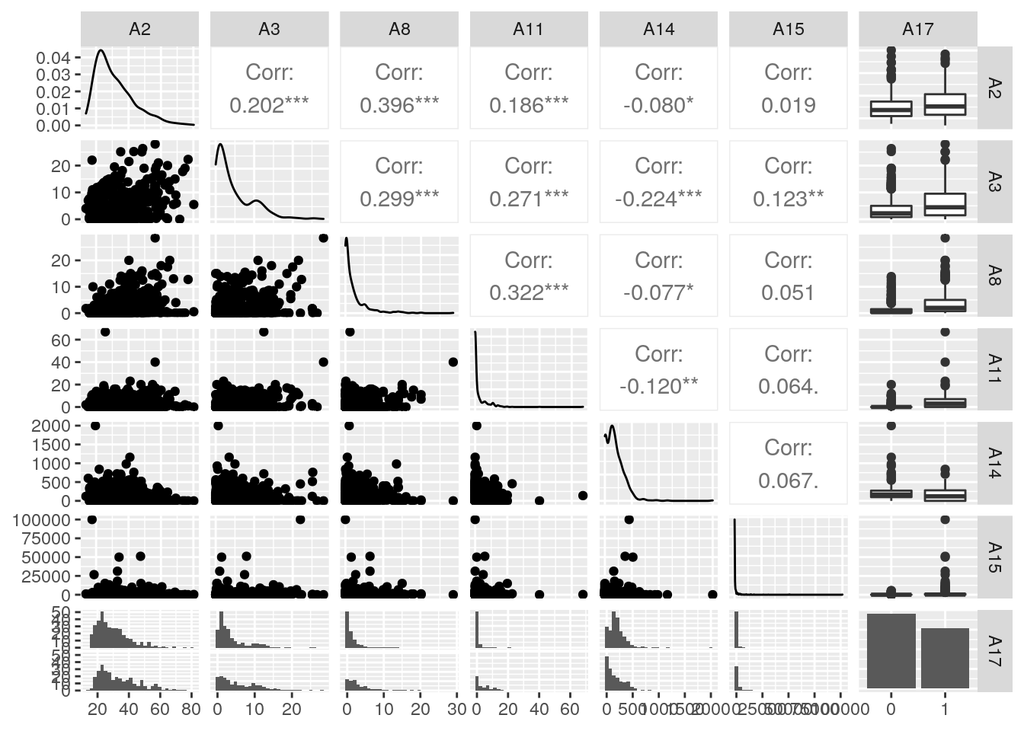

```r
# Inspeccion de variables
## Inspeccion de correlacion entre variables numerica y la variable dependiente [A17]
ggpairs(dt[,c(2,3,8,11,14,15,17)])
```

##### Interpretaciones de la grafica:

> - Se puede observar que existen algunas variables con correlacion significativa, lo cual es un aspecto imprtante a considerar tanto para la imputación de las variables con NAs, como en el caso de A2 <-> A8 o A2 <-> A3, las cuales permitiran un mejor resultado en la imputacion de la variable A2
> - Un aspecto importante es considirear que la correlación entre las variables es muy baja entre ellos.

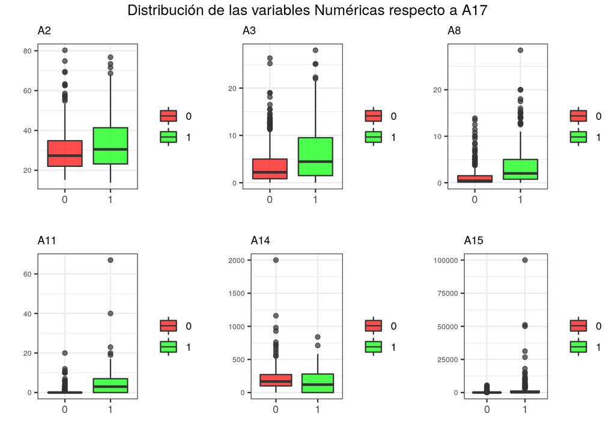

```r
# Pregunta 2 Graficas Correlacion
# creacion de lista de graficos de A17 contra el resto de variables
graphsByNumeric <- map(paste0("A", c(2,3,8,11,14,15)), ~graphByType(dt[,c(2,3,8,11,14,15,17)], .x)) # mapeamos las var[numericas] a gráficos
graphsByFactor <- map(paste0("A", c(1,4:7,9,10,12,13)), ~graphByType(dt[,c(1,4:7,9,10,12,13,17)], .x)) # mapeamos las var[factores] a gráficos
# dibujo de los gráficos para las variables numericas en un panel de 3 columnas
grid.arrange(grobs = graphsByNumeric, ncol = 3,
             top = "Distribución de las variables Numéricas respecto a A17")
```

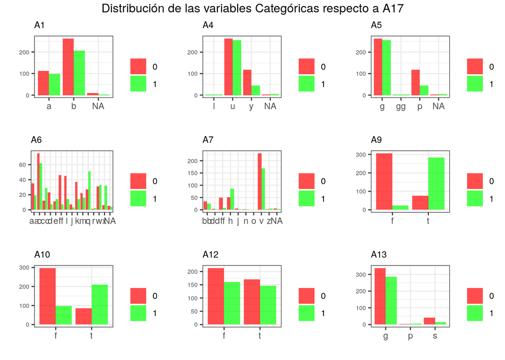

```r
 # dibujo de los gráficos para las variables categoricas en un panel de 3 columnas
grid.arrange(grobs = graphsByFactor, ncol = 3,
             top = "Distribución de las variables Categóricas respecto a A17")
```

##### Interpretaciones de las grafica:

[output not shown]

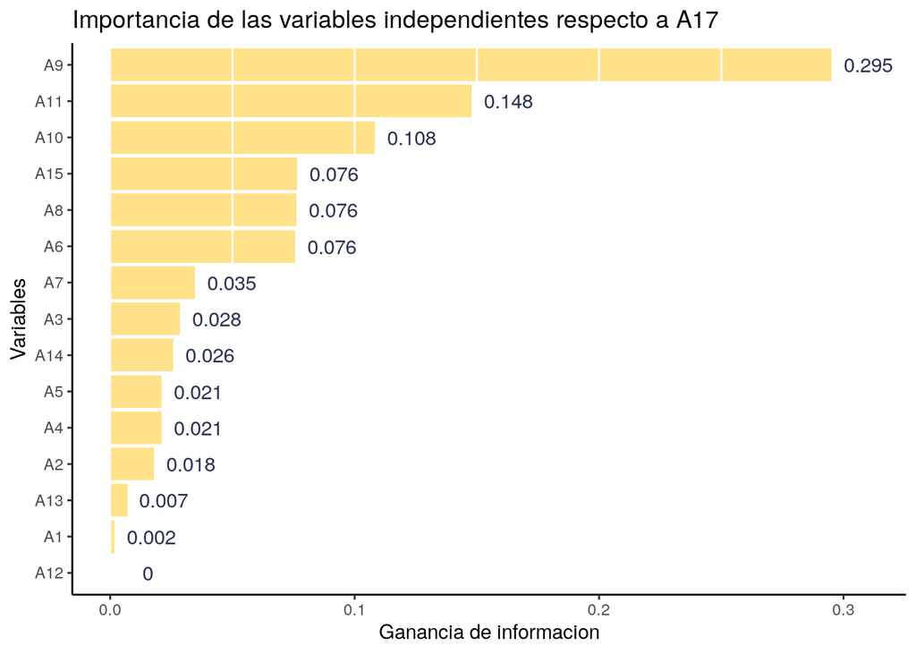

```r
# Presentar la información de ganancia de cada variable del dataset respecto a la variable dependiente
graphInfromationGain(dt[,-16])
```

##### Interpretaciones de la graficas:

> - Las variables con más influencia sobre la dependiente parecen ser la A9 y la A10. El calculo de la ganancia de información confirma la influencia de estas dos variables. Pero aparecen también en lugar destacado las variables A11 y A15, cuya influencia pasa desapercibida en el gráfico debido a que hay presencia de valores extremos. Se da el caso de que son las mismas variables con una grán presencia de ceros.

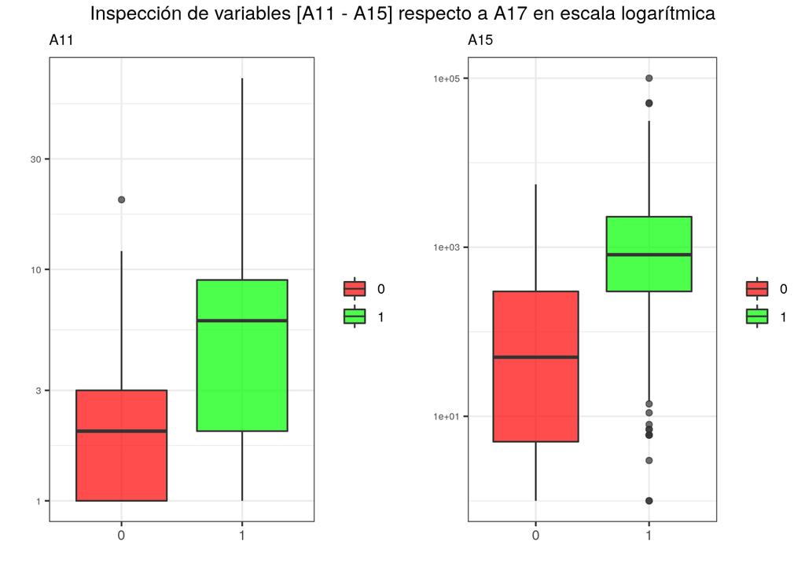

```r
# Inpseccion de las variables A11 y A15
graphVarsMax <- map(c("A11", "A15"), # seleccionamos las variables a maximizar
                           ~graphByType(dt, .x) +
                             scale_y_log10() +
                             theme(plot.subtitle = element_text(size = 6)))
grid.arrange(grobs = graphVarsMax, ncol = 2,
            top = "Inspección de variables [A11 - A15] respecto a A17 en escala logarítmica")
```

##### Interpretaciones de la graficas:

> - Se puede observar que las variables tienen un nivel de aporte a la variable objetivo una vez maximizada su escala, de igual manera se aprecia la presencia de datos atipicos.

##### ¿ Qué variables son mejores para separar los datos?

> - Del EDA (Análisis Exploratorio de los Datos) se puede deteterminar que las variables con mayor interes tanto para la imputación de datos como para el entrenamiento del modelo son :
> - A8 -> para tratamiento de los missing values por correlación con A2
> - A6, A8, A9, A10, A11, A15 -> para el entrenamiento del modelo
2. **Preparación de Dataset**

   **2.1 Paso EXTRA a Considerar**

   ```r
       # Tratamiento de Outliers de las variables [A11, A15]
       # Para este caso se opta por sustituir los outliers por NAs para q el algoritmo de missings determine el mejor valor
       # NOTA: Es recomendable eliminar Outliers
       dt <- fixOutliers(df=dt, colOtl="A11", nDs=3) # Aplicamos la función a [A11] con 3 desviaciones estandar
   ```

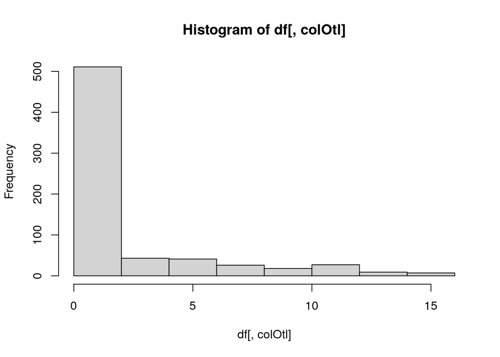

   ```r
       dt <- fixOutliers(df=dt, colOtl="A15", nDs=3) # Aplicamos la función a [A15] con 3 desviaciones estandar
   ```

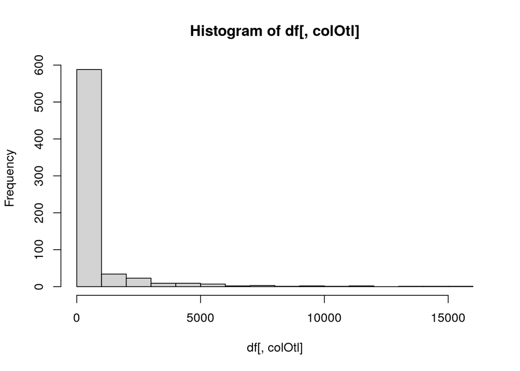

   **2.2 Imputación**

   ```r
       # Imputación de variables
       #colsMiss <- c(1,2,4:7,14) # Solo considero las variables con NAs
       #colsMiss <- c(1,2,4:8,14) # Agregamos las variables [A8] q tiene una correlación con las que se van a imputar
       colsMiss <- c(1,2,4:8,11,15,14) # Agregamos las variables [A8] por correlación y [A11,A15] imputar outliers
       dt <- fixMissing(dt, colsMiss)
   ```

   ```
   ##   missForest iteration 1 in progress...done!
   ##   missForest iteration 2 in progress...done!
   ##   missForest iteration 3 in progress...done!
   ```

   ```r
       summary(dt)
   ```

   ```
   ##  A1            A2              A3         A4       A5            A6
   ##  a:212   Min.   :13.75   Min.   : 0.000   l:  2   g :525   c      :137
   ##  b:478   1st Qu.:22.67   1st Qu.: 1.000   u:525   gg:  2   q      : 78
   ##          Median :28.62   Median : 2.750   y:163   p :163   w      : 64
   ##          Mean   :31.60   Mean   : 4.759                    i      : 63
   ##          3rd Qu.:38.23   3rd Qu.: 7.207                    ff     : 56
   ##          Max.   :80.25   Max.   :28.000                    aa     : 54
   ##                                                            (Other):238
   ##        A7            A8         A9      A10          A11         A12
   ##  v      :401   Min.   : 0.000   f:329   f:395   Min.   : 0.000   f:374
   ##  h      :138   1st Qu.: 0.165   t:361   t:295   1st Qu.: 0.000   t:316
   ##  bb     : 63   Median : 1.000                   Median : 0.000
   ##  ff     : 60   Mean   : 2.223                   Mean   : 2.128
   ##  j      :  8   3rd Qu.: 2.625                   3rd Qu.: 3.000
   ##  z      :  8   Max.   :28.500                   Max.   :16.000
   ##  (Other): 12
   ##  A13          A14              A15              A16            A17
   ##  g:625   Min.   :   0.0   Min.   :    0.0   Length:690         0:383
   ##  p:  8   1st Qu.:  80.0   1st Qu.:    0.0   Class :character   1:307
   ##  s: 57   Median : 160.0   Median :    5.0   Mode  :character
   ##          Mean   : 183.8   Mean   :  622.8
   ##          3rd Qu.: 273.5   3rd Qu.:  393.0
   ##          Max.   :2000.0   Max.   :15108.0
   ##
   ```

   ```r
       #dt[apply(is.na(dt), 2, sum)]
   ```

   ```r
   # Verificar variables con NA nuevamente
   checkNACols(dt)
   ```

   | countNAs |
   | --- |

   ```r
   # Verificar ganancia de información nuevamente
   viewAnomalies(dt[,-16])
   ```

   Variable

   q

   qNA

   pNA

   qZero

   pZero

   qDistinct

   type

   anomalous_percent

   A11

   690

   0

   395

   57.25%

   25

   Numeric

   57.25%

   A17

   690

   0

   383

   55.51%

   2

   Factor

   55.51%

   A15

   690

   0

   295

   42.75%

   240

   Numeric

   42.75%

   A14

   690

   0

   132

   19.13%

   183

   Numeric

   19.13%

   A8

   690

   0

   70

   10.14%

   132

   Numeric

   10.14%

   A3

   690

   0

   19

   2.75%

   215

   Numeric

   2.75%

   A1

   690

   0

   0

   2

   Factor

   A9

   690

   0

   0

   2

   Factor

   A10

   690

   0

   0

   2

   Factor

   A12

   690

   0

   0

   2

   Factor

   A4

   690

   0

   0

   3

   Factor

   A5

   690

   0

   0

   3

   Factor

   A13

   690

   0

   0

   3

   Factor

   A7

   690

   0

   0

   9

   Factor

   A6

   690

   0

   0

   14

   Factor

   A2

   690

   0

   0

   361

   Numeric

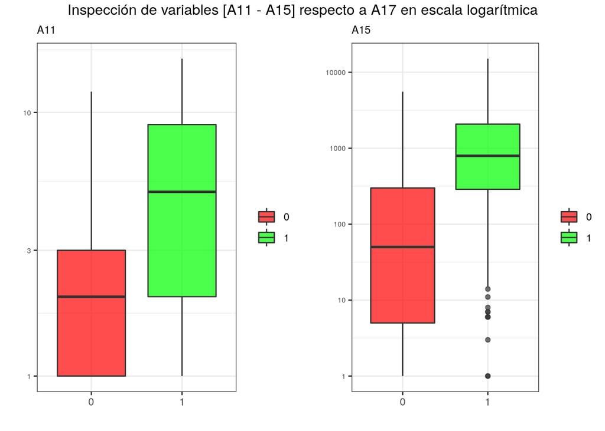

```r
# Inspección de las variables A11 y A15 luego de la imputacion y tratameinto de outliers
graphVarsMax <- map(c("A11", "A15"), # seleccionamos las variables a maximizar
                           ~graphByType(dt, .x) +
                             scale_y_log10() +
                             theme(plot.subtitle = element_text(size = 6)))
grid.arrange(grobs = graphVarsMax, ncol = 2,
            top = "Inspección de variables [A11 - A15] respecto a A17 en escala logarítmica")
```

##### Interpretaciones de la graficas:

> - Habiendose realizado el proceso de tratamiento de outliers a las variables A11 y A15, se logra establizar en cierto modo a las variables, aunque aun se persive una presencia de outliers en la variable A15. Se podria considerar para un otro caso aplicarle 2 desviaciones estandar para ver su comportamiento.

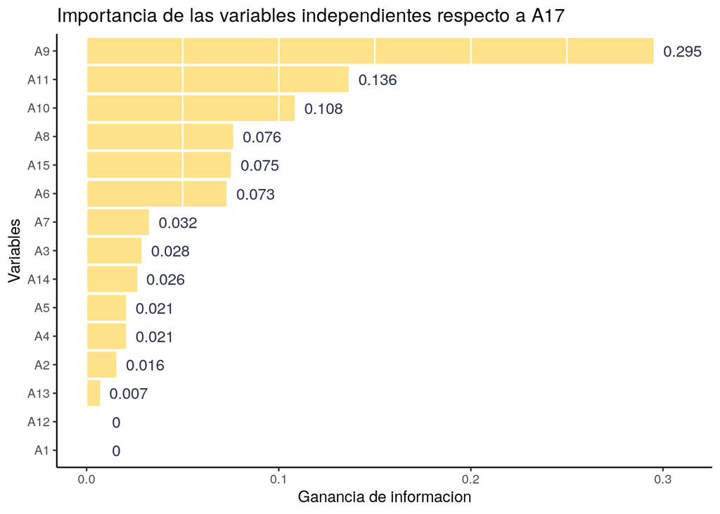

```r
# Verificamos nuevamente la ganacia de información
graphInfromationGain(dt[,-16])
```

   3.1. Seleccion datos de entrenamiento y test

   ```r
   # Dividir data de entrenamiento y test
   dt.train <-dt %>% slice(1:590) # Se escoje los primeros 590 para entrenamiento
   dt.test <- dt %>% slice(591:nrow(dt)) # Se separa los ultimos 100 para pruebas

   xIndp <- c(6,8,9,10,11,15) # Seleccionamos las variables de interes
   #xIndp <- c(1:15) # Para un estudi considerando todas las variables | -c(16,17)

   ## Data Farmateada para el entrenamiento
   x.train <- data.matrix(dt.train%>%select(all_of(xIndp))) #Para el analisis (Independientes) - revisar seleccionar las relevantes
   y.train <- data.matrix(dt.train$A17) # La de estudio - dependiente
   ```

   3.2 Entrenamiento

   ```r
   # Realizamos el entrenamiento del modelo
   model.train <-  trainModel(x=x.train ,y=y.train, nf=1 )
   model.train$cmpModels
   ```

   ```
   ## [1] 0.9195707 0.9185189
   ```

   ```r
   model.train$bestModelStr # Imprime el nombre del mejor modelo
   ```

   ```
   ## [1] "Modelo Optimo :: Ridge"
   ```

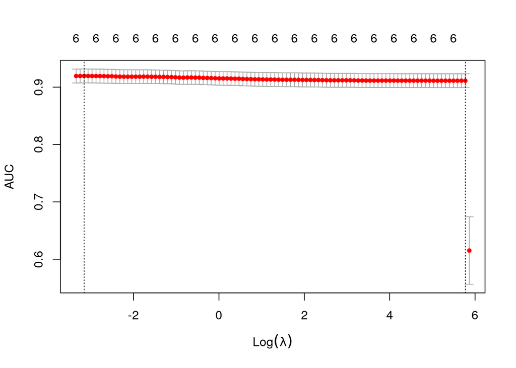

   ```r
   # Grafica del Mejor Modelo
   plot(model.train$bestModel)
   ```

##### **Explicaciones:**

   > - Se logra evidenciar que ambos modelos tiene resultados similares respescto a su AUC, por lo que tiende a variar la eleccion del mejor modelo para el proceso de predicciones, siendo ambos superior al 0.9 en el (cvm) error medio de validación cruzada.
   > - A partir de la grafica se podria deducir q el modelo es estable en gran medida ya que los mejores resultados se encuentran dentro de un error estandar que seria lo mas razonable para la predicción. AUnque existe un muy pequeño margen fuera del los lambas que determinarian como una mala predicción .

   3.3 Predicción

   ```r
   # Predicción con el mejor modelo
   # Poniendo a prueba el mejor modelo los los datos de test anteriormente seleccionados
   resModel <- testModel(model = model.train$bestModel, test = dt.test, xIndp = xIndp)
   head(sample_n(resModel$predOrigin, 30), n=30) # Presentamos una muestra de la prediccón
   ```

   |  | prediction | real |
   | --- | --- | --- |
   | 1 | 0 | 0 |
   | 2 | 0 | 0 |
   | 3 | 0 | 0 |
   | 4 | 0 | 0 |
   | 5 | 1 | 1 |
   | 6 | 0 | 1 |
   | 7 | 0 | 0 |
   | 8 | 0 | 0 |
   | 9 | 0 | 1 |
   | 10 | 0 | 0 |

   [output cut: 20 more lines]

4. **Logs Odds**

   ```r
   ## Aporta los log odds de las variables predictoras sobre la variable objetivo
   logodds <- tidy(coef(model.train$bestModel, s = model.train$bestModel$lambda.min))[c(1, 3)]
   names(logodds) <- c("Variable", "Beta")
   logodds$Beta <- round(logodds$Beta, 4)
   #generacion de tabla
   kable(logodds) %>% kable_styling(full_width = F, bootstrap_options = "condensed") %>%
    row_spec(0, color = "black", background = "lightgrey") %>%
    row_spec(which(logodds$Beta > 0.4), background = "#FFC32E") # Estilo a filas por condicion [qZero>0]
   ```

   | Variable | Beta |
   | --- | --- |
   | (Intercept) | -5.4957 |
   | A6 | 0.0374 |
   | A8 | 0.0766 |
   | A9 | 2.3210 |
   | A10 | 0.6347 |
   | A11 | 0.1147 |
   | A15 | 0.0002 |

##### **Interpretacion:**

   > - Se puede observar que las variables A9 y A10 son la que mayor infuencia al momento de la predicción.
   > - Se refleja al final q la variable A15 no aporta en gran media al modelo, considerando que dicha variable tenia un gran cantidad de outliers.
5. **Análisis del Módelo**

   ```r
   # Matriz de Confusión
    conf_matrix <- confusionMatrix(as.factor(resModel$pred),as.factor(resModel$y_test), mode="everything", positive = "1")
    conf_matrix$table
   ```

   ```
   ##           Reference
   ## Prediction  0  1
   ##          0 86  8
   ##          1  0  6
   ```

##### Observaciones:

   > - Se puede observar que el modelo esta sobrecargado para predecir bien los negativos